# dge

Jordan Lee

2/28/2020

This is a html version of dge.R as of end of day 2/28/20

```r
# Disclaimer: hardcoded names of patients in flat_matrix
# hard coded condition vector
####################
file_bulk <-'/Users/leejor/Ellrott_Lab/04_CSBC/cell-dissociation/data/01_process-bulkrna/07_ct_matrices/TESTDATA--UHR_Rep1_ERCC-Mix1_Build37-ErccTranscripts-chr22_COUNTmatrix.txt'
countsMECH_1_matrix_dir <- '/Users/leejor/Ellrott_Lab/04_CSBC/cell-dissociation/data/02_process-scrna/7319_Mech/'
countsENZ_1_matrix_dir <- '/Users/leejor/Ellrott_Lab/04_CSBC/cell-dissociation/data/02_process-scrna/7319_Enz/'
countsMECH_2_matrix_dir <- '/Users/leejor/Ellrott_Lab/04_CSBC/cell-dissociation/data/02_process-scrna/7320_Mech/'
countsENZ_2_matrix_dir <- '/Users/leejor/Ellrott_Lab/04_CSBC/cell-dissociation/data/02_process-scrna/7320_Enz/'
THRES = 0.1
output_sortedGenes = '/Users/leejor/Ellrott_Lab/04_CSBC/cell-dissociation/data/03_compare-bulk_scrna/scrna2bulk/geneOrdered_results.csv'
####################
```

```r
library(Seurat)
library(dplyr)
library(Matrix)
library(gdata)
library(DESeq2)
library(ggplot2)
library(pheatmap)
library(vsn)
library(RColorBrewer)
```

# Create combined matrices of mech and enz

Read in files and create pseudo-bulk (take the sum of raw gene counts across all cell barcodes and report that as the pseudo-bulk gene count)

# Run DGE

```r
#####################
# DGE
#####################
dds <- DESeqDataSetFromMatrix(countData = flat_matrix, colData = meta_data, design = ~ condition)
```

`DESeq()` details:

- Function runs: 1) est of size factors, est of dispersions, negative binomial generalized linear model (GLM) fitting and wald stats

```r
dds <- DESeq(dds, test ='Wald')
```

`results()` details (these are outlined in the object printout below too):

- Adjusted pvals = BH corrected
- User specified alpha val to use for adjusted pval thresholding for FDR analysis
- Wald test to assess model fit (compared to likelihood ratio test). Wald test fits full model –> conducts tests for each gene to assess distance from 0 *- using the full model coefficent(s) and their standard error(s)* –> genes with coefficients significantly different than 0 will show this in their log2 fold change (and coefficient is reported as the log2fold change). - several studies have found that **Wald-log test** is better for RNA-seq data than others.

```r
res <- results(dds, alpha=THRES, pAdjustMethod = 'BH', test='Wald')
( mcols(res)$description ) # info
```

```
## [1] "mean of normalized counts for all samples"
## [2] "log2 fold change (MLE): condition mech vs enz"
## [3] "standard error: condition mech vs enz"
## [4] "Wald statistic: condition mech vs enz"
## [5] "Wald test p-value: condition mech vs enz"
## [6] "BH adjusted p-values"
```

# Visuals

#### 1. Select diff shrinking method

Options: apeglm, normal, ashr

```
## [1] "Intercept"             "condition_mech_vs_enz"
```

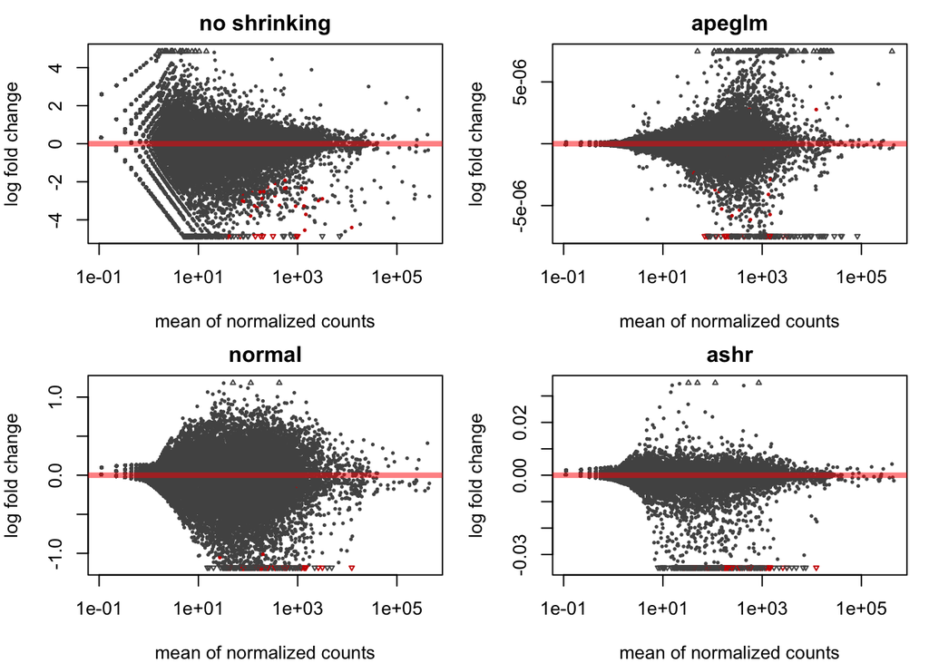

#### 2. Inspect individual genes

For a given gene, what are the log10 counts between groups?

```
## [1] 5348
```

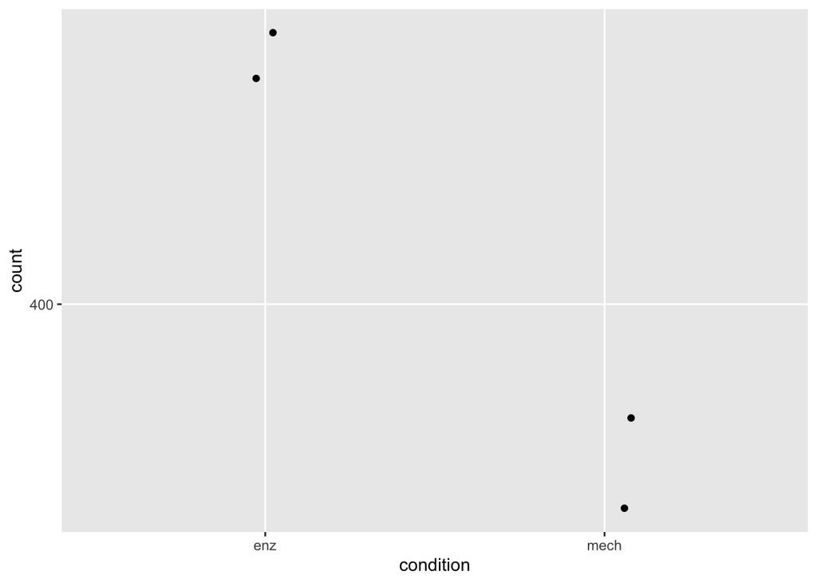

#### 3. Top DGE genes

```
##
## out of 23622 with nonzero total read count
## adjusted p-value < 0.1
## LFC > 0 (up)       : 0, 0%
## LFC < 0 (down)     : 41, 0.17%
## outliers [1]       : 0, 0%
## low counts [2]     : 10301, 44%
## (mean count < 16)
## [1] see 'cooksCutoff' argument of ?results
## [2] see 'independentFiltering' argument of ?results
```

```
## log2 fold change (MLE): condition mech vs enz
## Wald test p-value: condition mech vs enz
## DataFrame with 41 rows and 6 columns
##                 baseMean    log2FoldChange             lfcSE              stat
##                <numeric>         <numeric>         <numeric>         <numeric>
## COL6A3  913.006994461412 -3.27959728479076 0.561880767533133 -5.83682068206288
## LACRT   995.058136725316 -26.8779434019642  4.78478224442755 -5.61738069339869
## PLA2G2A  929.88731485777 -26.3940816271804   4.7847847657951 -5.51625264648543
## ADH1B   318.755535890177 -25.3219967773718  4.78485923090439 -5.29210903715252
## DLK1    180.214360694516 -24.5440338955817   4.7849463173063 -5.12942722195446
## ...                  ...               ...               ...               ...
## MYL9    246.544433730332 -2.28016161827184 0.611448172941387 -3.72911674149433
## COL16A1  78.254109968047 -2.69536915092749 0.727661627811657 -3.70415183089074
## TBX18   27.0295476765958 -7.44035898326883  2.05017321960227 -3.62913675397254
## FGFBP1  188.076614334661 -3.17650948665503  0.87702456394519 -3.62191621220492
## WISP2   200.203503873339 -6.53778832460461  1.81083303483067 -3.61037610804133
##                       pvalue                 padj
##                    <numeric>            <numeric>
## COL6A3  5.32063044800184e-09 7.08761181978326e-05
## LACRT   1.93873952510388e-08 0.000129129746069544
## PLA2G2A 3.46304321494272e-08  0.00015377066222084
## ADH1B   1.20913761193482e-07 0.000402673053214594
## DLK1    2.90625100703155e-07 0.000774283393293345
## ...                      ...                  ...
## MYL9    0.000192152120809101   0.0691799567918387
## COL16A1 0.000212099199345498   0.0743519324863522
## TBX18   0.000284370572786946    0.097130779489613
## FGFBP1  0.000292428844899043   0.0973861160725037
## WISP2   0.000305753321611914   0.0993399999315196
```

And reporting info

```
## [1] "Number of signficant genes and alpha:"
```

```
## [1] 41
```

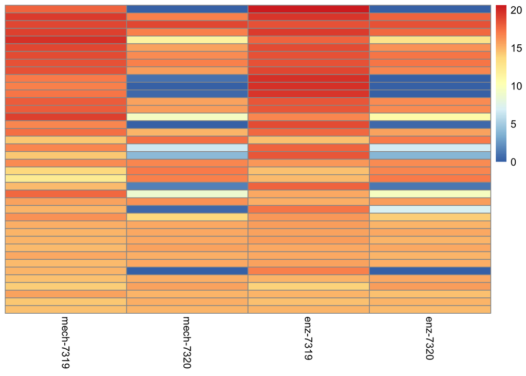

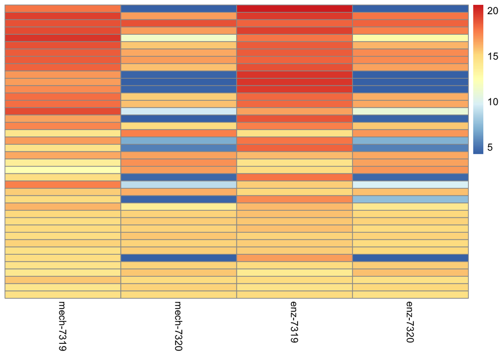

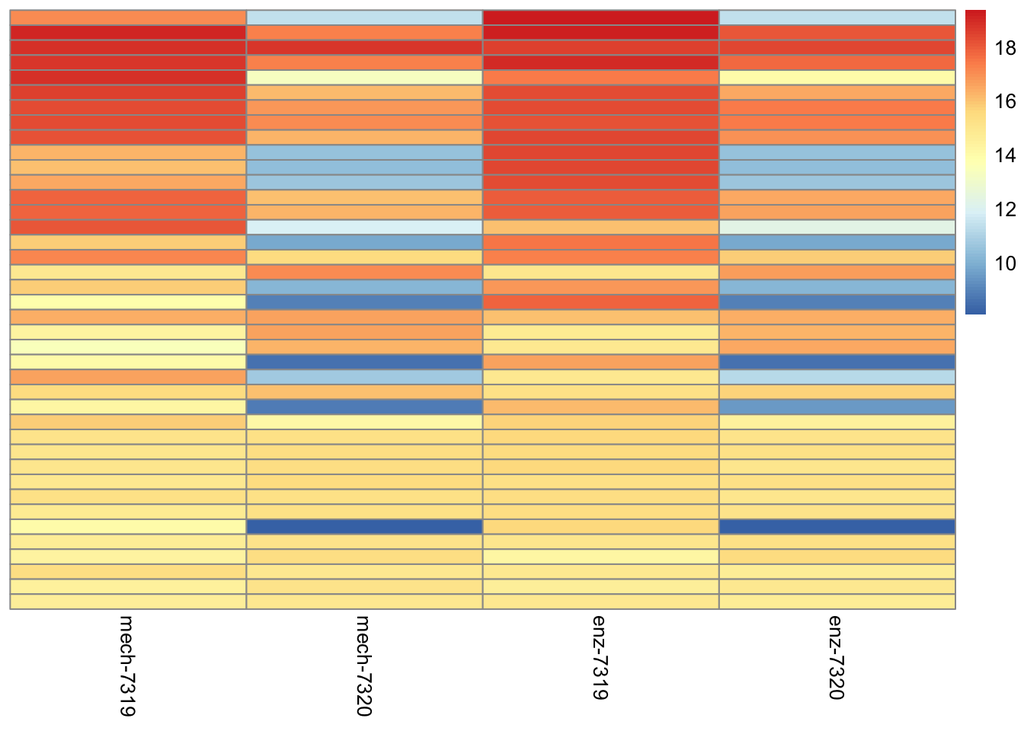

#### Clustering methods

Options for visuals for presentation: Heatmap or PCA

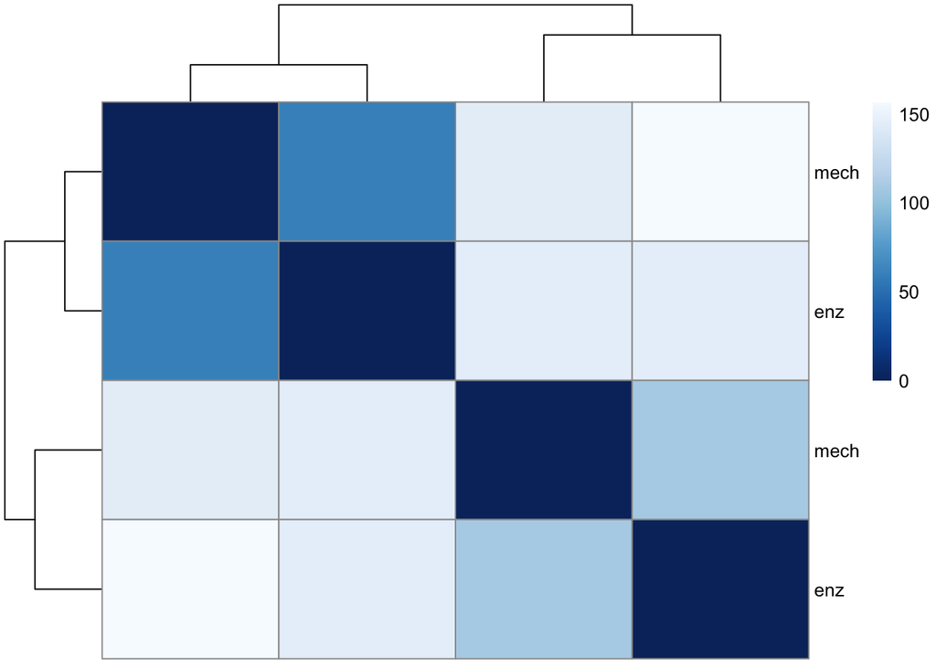

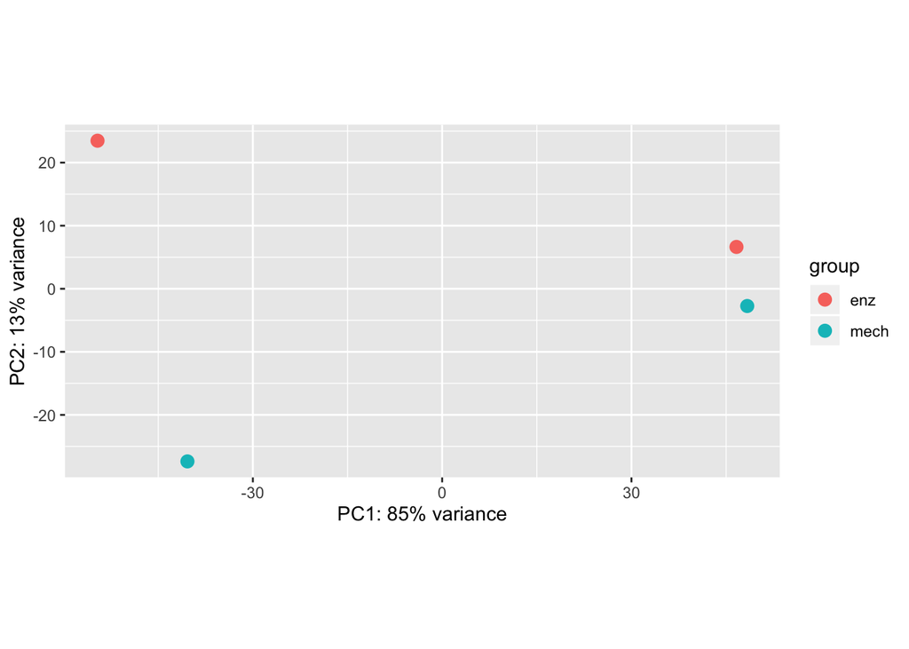